# EDA_data_association

### familysize

- 가족구성원수에 따른 투표참여량

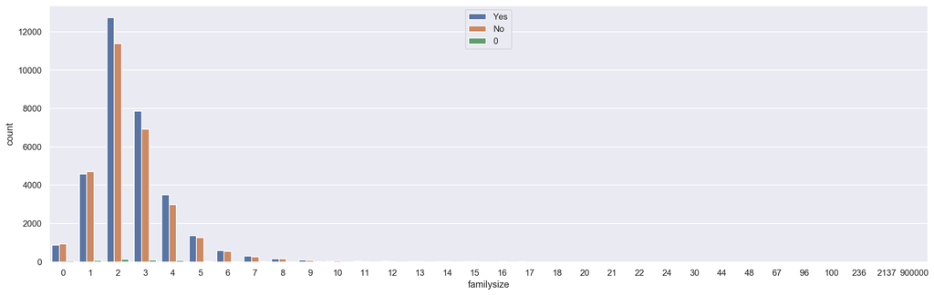

```python
plt.figure(figsize=(20, 6))
sns.countplot(x=df['familysize'], hue=df['voted'])
plt.legend(loc='upper center');
```

- 가족구성원수에 따른 투표참여율

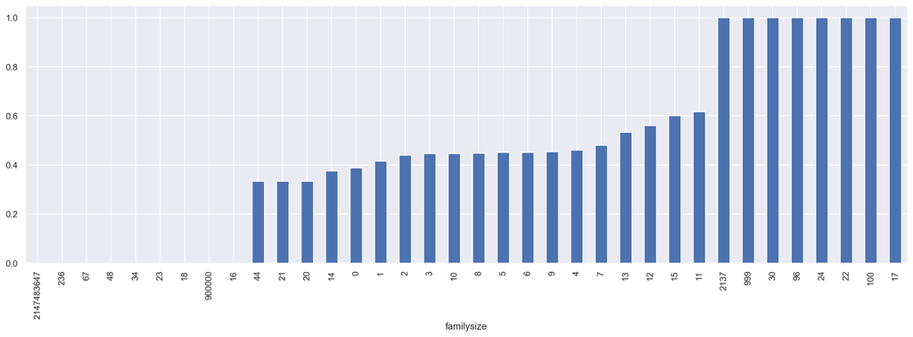

```python
plt.figure(figsize=(20, 6))
test.voting_rates("familysize");
```

### major

- 전공 별 테스트 참여자 수

```python
majors = df['major'].str.lower()
majors = majors.str.strip()
majors.value_counts()
```

```
psychology                              3367
business                                1988
engineering                             1734
english                                 1501
computer science                        1435
                                        ...
business & management and psychology       1
lái tàu                                    1
education and music                        1
economics politics and law                 1
òõêõ                                       1
Name: major, Length: 6380, dtype: int64
```

### country

- 소속 서버 지역별 투표참여량

[figure not shown]

```python
plt.figure(figsize=(12, 6))
sns.countplot(x=df['country'], hue=df['voted'])
plt.legend(loc='upper center');
```

- 참여자 100명 이상 소속 서버 지역별 투표참여량

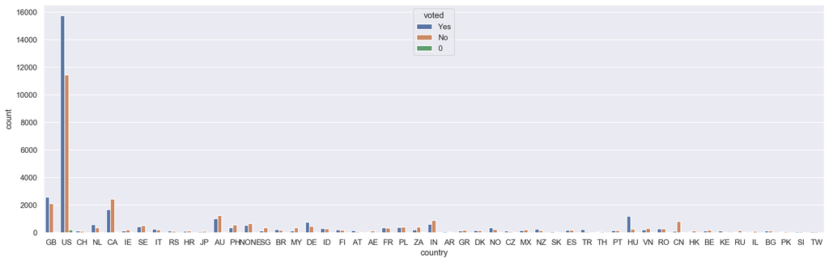

```python
plt.figure(figsize=(20, 6))
sns.countplot(x=df_cntr_100['country'], hue=df_cntr_100['voted']);
```

- 참여자 100명 이상 소속 서버 지역별 투표참여율

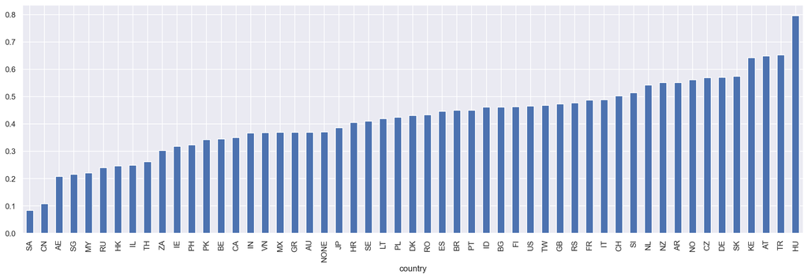

```python
plt.figure(figsize=(20, 6))
df_name = pd.crosstab(df_cntr_100['country'], df_cntr_100['voted'])
df_name["diff"] = (df_name["Yes"]/(df_name["Yes"]+df_name["No"]+df_name["0"]))
df_name["diff"].sort_values().plot(kind="bar");
```

### screen size

- 참여자 사용 스크린 사이즈별 투표참여량

[figure not shown]

```python
plt.figure(figsize=(12, 6))
sns.countplot(x=df['screenw'], hue=df['voted'])
plt.legend(loc='upper center');
```

- 100명 이상 참여자가 사용하는 스크린 사이즈(가로)별 투표참여율

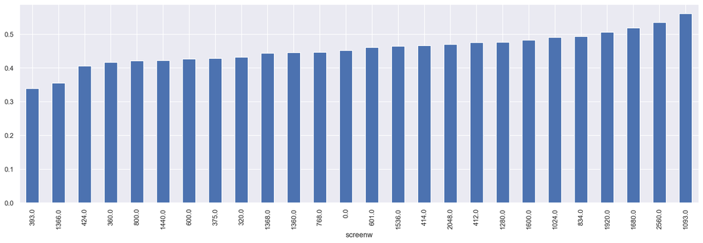

```python
plt.figure(figsize=(20, 6))
scw = df_scw[df_scw["screenw"]>100].index
idx_list = []
for idx, x in enumerate(df['screenw']):
    if x in scw :
        idx_list.append(idx)
scw_100 = df.iloc[idx_list]

df_name = pd.crosstab(scw_100['screenw'], scw_100['voted'])
df_name["diff"] = (df_name["Yes"]/(df_name["Yes"]+df_name["No"]+df_name["0"]))
df_name["diff"].sort_values().plot(kind="bar");
```

[figure not shown]

```python
plt.figure(figsize=(12, 6))
sns.countplot(x=df['screenh'], hue=df['voted'])
plt.legend(loc='upper center');
```

- 100명 이상 참여자가 사용하는 스크린 사이즈(세로)별 투표참여율

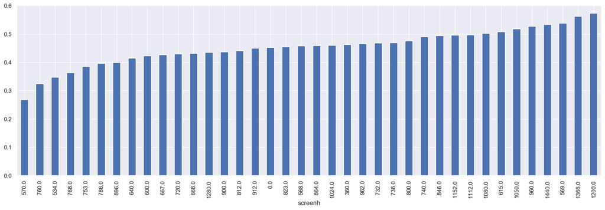

```python
plt.figure(figsize=(20, 6))
scw = df_scw[df_scw["screenh"]>100].index
idx_list = []
for idx, x in enumerate(df['screenh']):
    if x in scw :
        idx_list.append(idx)
scw_100 = df.iloc[idx_list]

df_name = pd.crosstab(scw_100['screenh'], scw_100['voted'])
df_name["diff"] = (df_name["Yes"]/(df_name["Yes"]+df_name["No"]+df_name["0"]))
df_name["diff"].sort_values().plot(kind="bar");
```

### duration

- 테스트 참여 소요시간별 투표참여량

[figure not shown]

```python
plt.figure(figsize=(12, 6))
sns.countplot(x=df['introelapse'], hue=df['voted'])
plt.legend(loc='upper center');
```

- 350명 이상 참여자가 초기화면에 머문시간대별 투표참여율

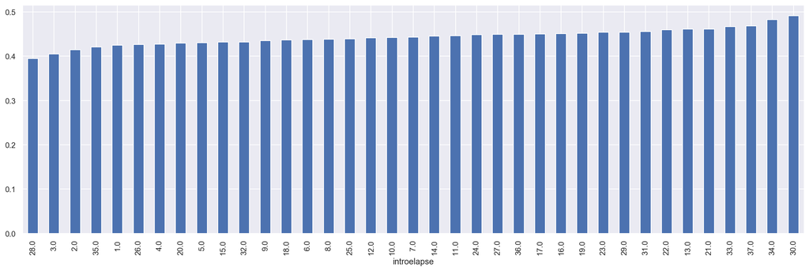

```python
plt.figure(figsize=(20, 6))
scw = df_scw[df_scw["introelapse"]>350].index
idx_list = []
for idx, x in enumerate(df['introelapse']):
    if x in scw :
        idx_list.append(idx)
scw_100 = df.iloc[idx_list]

df_name = pd.crosstab(scw_100['introelapse'], scw_100['voted'])
df_name["diff"] = (df_name["Yes"]/(df_name["Yes"]+df_name["No"]+df_name["0"]))
df_name["diff"].sort_values().plot(kind="bar");
```

[figure not shown]

```python
plt.figure(figsize=(12, 6))
sns.countplot(x=df['testelapse'], hue=df['voted'])
plt.legend(loc='upper center');
```

- 400명 이상 참여자의 테스트 진행시간대별 투표참여율

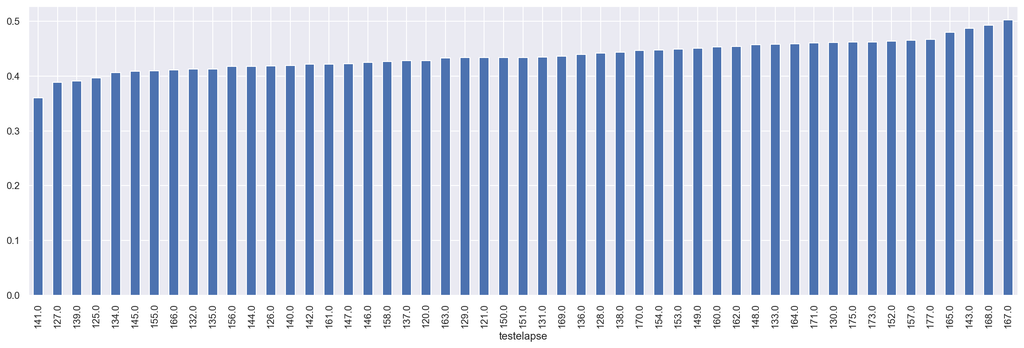

```python
plt.figure(figsize=(20, 6))
scw = df_scw[df_scw["testelapse"]>400].index
idx_list = []
for idx, x in enumerate(df['testelapse']):
    if x in scw :
        idx_list.append(idx)
scw_100 = df.iloc[idx_list]

df_name = pd.crosstab(scw_100['testelapse'], scw_100['voted'])
df_name["diff"] = (df_name["Yes"]/(df_name["Yes"]+df_name["No"]+df_name["0"]))
df_name["diff"].sort_values().plot(kind="bar");
```

[figure not shown]

```python
plt.figure(figsize=(12, 6))
sns.countplot(x=df['surveyelapse'], hue=df['voted'])
plt.legend(loc='upper center');
```

- 400명 이상 참여자의 인적사항 설문조사 진행시간대별 투표참여율

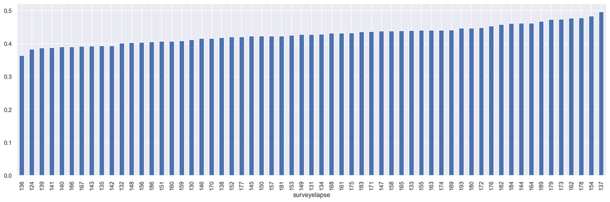

```python
plt.figure(figsize=(20, 6))
scw = df_scw[df_scw["surveyelapse"]>400].index
idx_list = []
for idx, x in enumerate(df['surveyelapse']):
    if x in scw :
        idx_list.append(idx)
scw_100 = df.iloc[idx_list]

df_name = pd.crosstab(scw_100['surveyelapse'], scw_100['voted'])
df_name["diff"] = (df_name["Yes"]/(df_name["Yes"]+df_name["No"]+df_name["0"]))
df_name["diff"].sort_values().plot(kind="bar");
```